# IODS course project

Boris Vassilev

# About the project

This is a course about statistics with open source tools: R, RStudio, and so on.

This course is massive!

Every week there will be a submission with a deadline on the following Sunday at 23:55. Late submissions will not be accepted.

After that, three other projects will be assigned for peer review. The deadline for the peer reviews is Wednesday the same week at 23:55.

The exercises and the peer reviews are all that is required for this course.

[Here is the link to my GitHub repository](https://github.com/borisvassilev/IODS-project).

# Regression and model validation

Load the wrangled data and take a look at it.

```r
learning2014 <- read.table("data/learning2014.tsv", sep = "\t")
str(learning2014)
```

```
## 'data.frame':    166 obs. of  7 variables:
##  $ gender  : Factor w/ 2 levels "F","M": 1 2 1 2 2 1 2 1 2 1 ...
##  $ age     : int  53 55 49 53 49 38 50 37 37 42 ...
##  $ attitude: num  3.7 3.1 2.5 3.5 3.7 3.8 3.5 2.9 3.8 2.1 ...
##  $ deep    : num  3.58 2.92 3.5 3.5 3.67 ...
##  $ stra    : num  3.38 2.75 3.62 3.12 3.62 ...
##  $ surf    : num  2.58 3.17 2.25 2.25 2.83 ...
##  $ points  : int  25 12 24 10 22 21 21 31 24 26 ...
```

Plot the data.

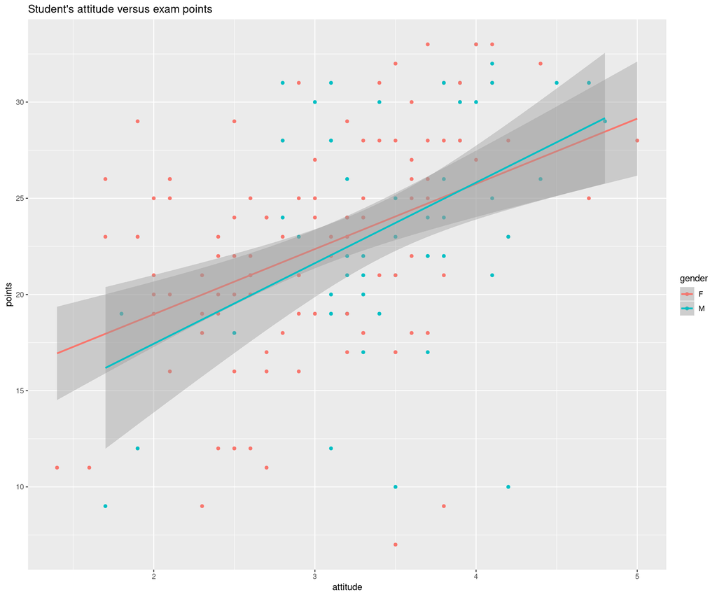

```r
library(ggplot2)

# initialize plot with data and aesthetic mapping
p1 <- ggplot(learning2014, aes(x = attitude, y = points, col = gender))

# define the visualization type (points)
p2 <- p1 + geom_point()

# add a regression line
p3 <- p2 + geom_smooth(method = "lm")

# add a main title and draw the plot
p4 <- p3 + ggtitle("Student's attitude versus exam points")

# draw the plot
p4
```

There is a positive correlation between attitude and points. There is no obvious difference between the two genders. Interestingly, there are only two genders.

Now, plot all possible pairs of variables as scatter plots:

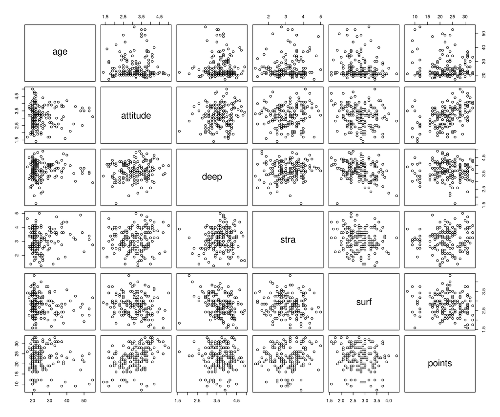

```r
pairs(learning2014[-1])
```

This is not very informative, since the plots are very small and there is no regression line to help us imagine which way the correlation goes.

Drawing more advanced plots:

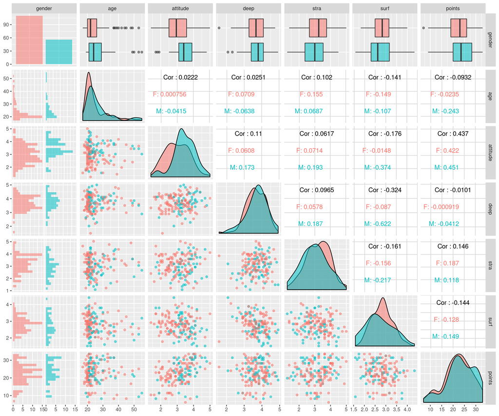

```r
library(GGally)
library(ggplot2)

# create a more advanced plot matrix with ggpairs()
p <- ggpairs(learning2014, mapping = aes(col = gender, alpha = .3), lower = list(combo = wrap("facethist", bins = 20)))

# draw the plot
p
```

Age seems to follow a Poisson distribution, probably because the subjects are students. The rest of the variables seem to have a normal distribution, as expected.

Apparently, attitude and points have the highest correlation by far.

In addition, there is a negative correlation between surf and deep.

There is a slight negative correlation between surf and points, surf and age, and surf and stra, as well as a positive correlation between stra and points.

Now, a regression analysis using the three variables that had the highest individual correlation with points:

```r
# create a regression model with three explanatory variables
my_model2 <- lm(points ~ attitude + stra + surf, data = learning2014)

# print out a summary of the model
summary(my_model2)
```

```
##
## Call:
## lm(formula = points ~ attitude + stra + surf, data = learning2014)
##
## Residuals:
##      Min       1Q   Median       3Q      Max
## -17.1550  -3.4346   0.5156   3.6401  10.8952
##
## Coefficients:
##             Estimate Std. Error t value Pr(>|t|)
## (Intercept)  11.0171     3.6837   2.991  0.00322 **
## attitude      3.3952     0.5741   5.913 1.93e-08 ***
## stra          0.8531     0.5416   1.575  0.11716
## surf         -0.5861     0.8014  -0.731  0.46563
## ---
## Signif. codes:  0 '***' 0.001 '**' 0.01 '*' 0.05 '.' 0.1 ' ' 1
##
## Residual standard error: 5.296 on 162 degrees of freedom
## Multiple R-squared:  0.2074, Adjusted R-squared:  0.1927
## F-statistic: 14.13 on 3 and 162 DF,  p-value: 3.156e-08
```

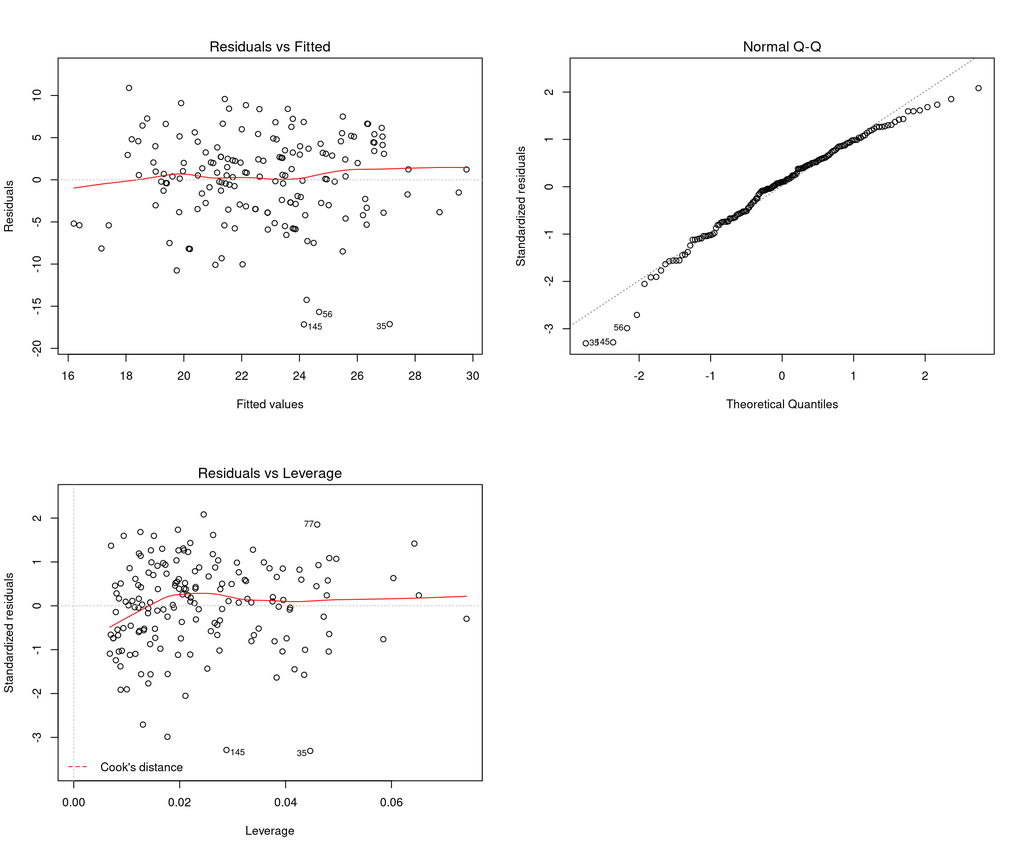

```r
par(mfrow = c(2,2))
plot(my_model2, which = c(1, 2, 5))
```

# Logistic regression

## Data

The data was joined by using following columns as surrogate identifiers for students: school, sex, age, address, famsize, Pstatus, Medu, Fedu, Mjob, Fjob, reason, nursery, internet.

Defined two new variables: alc_use and high_use.

```r
alc <- read.csv("data/alc.csv")
str(alc)
```

```
## 'data.frame':    382 obs. of  35 variables:
##  $ school    : Factor w/ 2 levels "GP","MS": 1 1 1 1 1 1 1 1 1 1 ...
##  $ sex       : Factor w/ 2 levels "F","M": 1 1 1 1 1 2 2 1 2 2 ...
##  $ age       : int  18 17 15 15 16 16 16 17 15 15 ...
##  $ address   : Factor w/ 2 levels "R","U": 2 2 2 2 2 2 2 2 2 2 ...
##  $ famsize   : Factor w/ 2 levels "GT3","LE3": 1 1 2 1 1 2 2 1 2 1 ...
##  $ Pstatus   : Factor w/ 2 levels "A","T": 1 2 2 2 2 2 2 1 1 2 ...
##  $ Medu      : int  4 1 1 4 3 4 2 4 3 3 ...
##  $ Fedu      : int  4 1 1 2 3 3 2 4 2 4 ...
##  $ Mjob      : Factor w/ 5 levels "at_home","health",..: 1 1 1 2 3 4 3 3 4 3 ...
##  $ Fjob      : Factor w/ 5 levels "at_home","health",..: 5 3 3 4 3 3 3 5 3 3 ...
##  $ reason    : Factor w/ 4 levels "course","home",..: 1 1 3 2 2 4 2 2 2 2 ...
##  $ nursery   : Factor w/ 2 levels "no","yes": 2 1 2 2 2 2 2 2 2 2 ...
##  $ internet  : Factor w/ 2 levels "no","yes": 1 2 2 2 1 2 2 1 2 2 ...
##  $ guardian  : Factor w/ 3 levels "father","mother",..: 2 1 2 2 1 2 2 2 2 2 ...
```

[output cut: 21 more lines]

## Predictors of high alcohol consumption

The following four variables were chosen:

goout, sex, studytime, and romantic.

The hypothesis is that going out leads to dringking and males drink more because they are heavier on average. Furthermore, drinking and going out leaves less time for studying. Being in a relationship should reduce alcohol consumption since there is no need to get wasted and meet people.

### Data exploration

Explore the variables of interest:

```r
library(tidyr)
library(dplyr)
library(ggplot2)

alc %>% group_by(high_use) %>% summarise(count = n(), mean_goout=mean(goout),
                                         mean_studytime=mean(studytime))
```

```
## # A tibble: 2 x 4
##   high_use count mean_goout mean_studytime
##   <lgl>    <int>      <dbl>          <dbl>
## 1 FALSE      268       2.85           2.15
## 2 TRUE       114       3.72           1.77
```

```r
alc %>% group_by(high_use, sex) %>% summarise(count = n())
```

```
## # A tibble: 4 x 3
## # Groups:   high_use [?]
##   high_use sex   count
##   <lgl>    <fct> <int>
## 1 FALSE    F       156
## 2 FALSE    M       112
## 3 TRUE     F        42
## 4 TRUE     M        72
```

```r
alc %>% group_by(high_use, romantic) %>% summarise(count = n())
```

```
## # A tibble: 4 x 3
## # Groups:   high_use [?]
##   high_use romantic count
##   <lgl>    <fct>    <int>
## 1 FALSE    no         180
## 2 FALSE    yes         88
## 3 TRUE     no          81
## 4 TRUE     yes         33
```

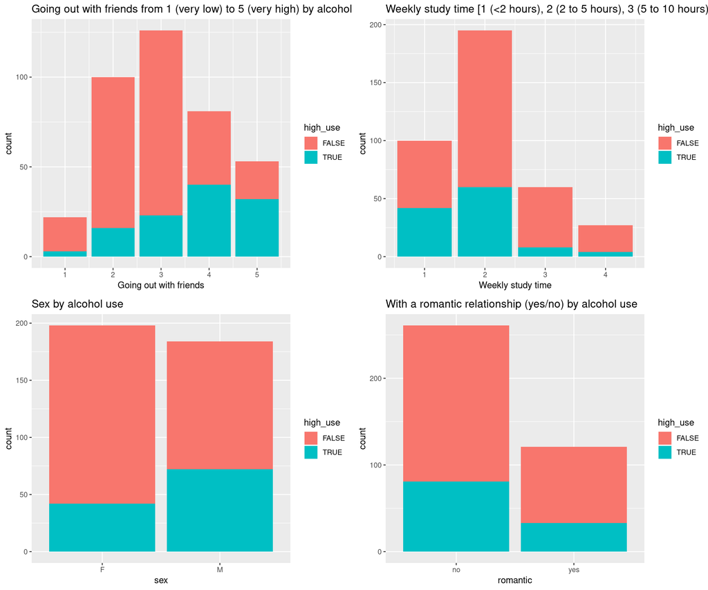

```r
g_goout <- ggplot(alc, aes(x = goout, fill=high_use)) +
  geom_bar() + xlab("Going out with friends") +
  ggtitle("Going out with friends from 1 (very low) to 5 (very high) by alcohol use")

g_studytime <- ggplot(alc, aes(x = studytime, fill=high_use)) +
  geom_bar() + xlab("Weekly study time") +
  ggtitle("Weekly study time [1 (<2 hours), 2 (2 to 5 hours), 3 (5 to 10 hours), or 4 (>10 hours)] by alchol use")

g_sex <- ggplot(alc, aes(x = sex, fill=high_use)) +
  geom_bar() +
  ggtitle("Sex by alcohol use")

g_romantic <- ggplot(alc, aes(x = romantic, fill=high_use)) +
  geom_bar() +
  ggtitle("With a romantic relationship (yes/no) by alcohol use")

# Arrange the plots into a grid
library("gridExtra")
grid.arrange(g_goout, g_studytime, g_sex, g_romantic, ncol=2, nrow=2)
```

In summary, all parts of the hypothesis seem to be correct.

### Fitting a logistic regression model

Fit a logistic regression model using high_use as the target variable and goout, studytime, sex, and romantic as explanatory variables.

```r
m <- glm(high_use ~ goout + studytime + sex + romantic, data = alc, family = "binomial")
```

Variables goout, studytime and sex are associated with alcohol consumption.

High alcohol consumption is associated with going out (as expected).

Males who drink less study more.

Summary of the model:

```r
summary(m)
```

```
##
## Call:
## glm(formula = high_use ~ goout + studytime + sex + romantic,
##     family = "binomial", data = alc)
##
## Deviance Residuals:
##     Min       1Q   Median       3Q      Max
## -1.7365  -0.8114  -0.5009   0.9081   2.6642
##
## Coefficients:
##             Estimate Std. Error z value Pr(>|z|)
## (Intercept)  -2.6988     0.5712  -4.725 2.30e-06 ***
## goout         0.7536     0.1187   6.350 2.15e-10 ***
## studytime    -0.4774     0.1683  -2.837  0.00456 **
## sexM          0.6657     0.2585   2.576  0.01000 *
## romanticyes  -0.1424     0.2699  -0.528  0.59767
## ---
## Signif. codes:  0 '***' 0.001 '**' 0.01 '*' 0.05 '.' 0.1 ' ' 1
##
## (Dispersion parameter for binomial family taken to be 1)
##
##     Null deviance: 465.68  on 381  degrees of freedom
## Residual deviance: 393.67  on 377  degrees of freedom
## AIC: 403.67
##
## Number of Fisher Scoring iterations: 4
```

Coefficients of the model as odds ratios and their confidence intervals:

```r
or <- coef(m) %>% exp
ci <- confint(m) %>% exp
cbind(or, ci)
```

```
##                     or      2.5 %    97.5 %
## (Intercept) 0.06728696 0.02129867 0.2010636
## goout       2.12456419 1.69404697 2.7003422
## studytime   0.62040325 0.44145946 0.8558631
## sexM        1.94589655 1.17538595 3.2443631
## romanticyes 0.86724548 0.50714091 1.4648961
```

In summary, 1 unit increase in goout is associated with 2.1 increase in likelihood of high alcohol consumption.

1 unit increase in studytime is associated with 0.6 lower likelihood of high alcohol consumption.

Being male is associated with 1.9 times increase in likelihood of high alcohol consumption compared to being female.

Being in a romantic relationship is **not** significantly associated with a change in likelihood of high alcohol consumption, so the hypothesis was wrong.

### Performance of the model

Fit a logistic model with the explanatory variables that were statistically significantly associated to high or low alcohol consumption:

```r
m <- glm(high_use ~ goout + studytime + sex, data = alc, family = "binomial")
```

Prediction performance of the model:

```r
probability <- predict(m, type="response")
alc <- mutate(alc, probability=probability)
alc <- mutate(alc, prediction=probability > 0.5)
table(high_use = alc$high_use, prediction = alc$prediction)
```

```
##         prediction
## high_use FALSE TRUE
##    FALSE   250   18
##    TRUE     76   38
```

The model is better at predicting low alcohol consumption than high alcohol consumption.

Visualizing the class, the predicted probabilities, and the predicted class:

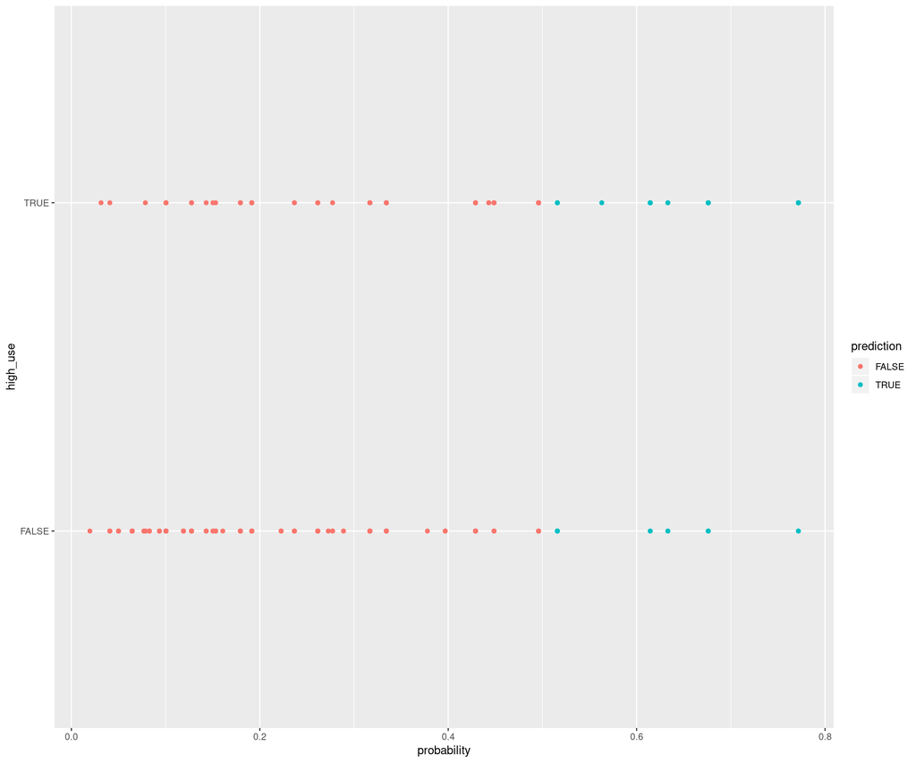

```r
g <- ggplot(alc, aes(x = probability, y = high_use, col=prediction))
g + geom_point()
```

Calculate the total proportion of misclassified individuals using the regression model. Use a simple guessing strategy where everyone is classified to be in the most prevalent class:

```r
loss_func <- function(class, prob) {
  n_wrong <- abs(class - prob) > 0.5
  mean(n_wrong)
}

loss_func(class = alc$high_use, prob = alc$probability)
```

```
## [1] 0.2460733
```

```r
loss_func(class = alc$high_use, prob = 0)
```

```
## [1] 0.2984293
```

Using the regression model, 24.6% of the individuals are misclassified, compared to 29.8 % of misclassified individuals if guessing that everybody belongs to the low use of alcohol class. The model seems to provide modest improvement to the simple guess of the most prevalent class.

### Cross-validation

Perform 10-fold cross-validation of the model to estimate the performance of the model on unseen data. The performance of the model is measured with proportion of misclassified individuals. The mean prediction error in the test set:

```r
library(boot)
cv <- cv.glm(data = alc, cost = loss_func, glmfit = m, K = 10)
cv$delta[1]
```

```
## [1] 0.2382199
```

### Models with different number of predictors

Construct models with different number of predictors and calculate the test set and training set prediction errors:

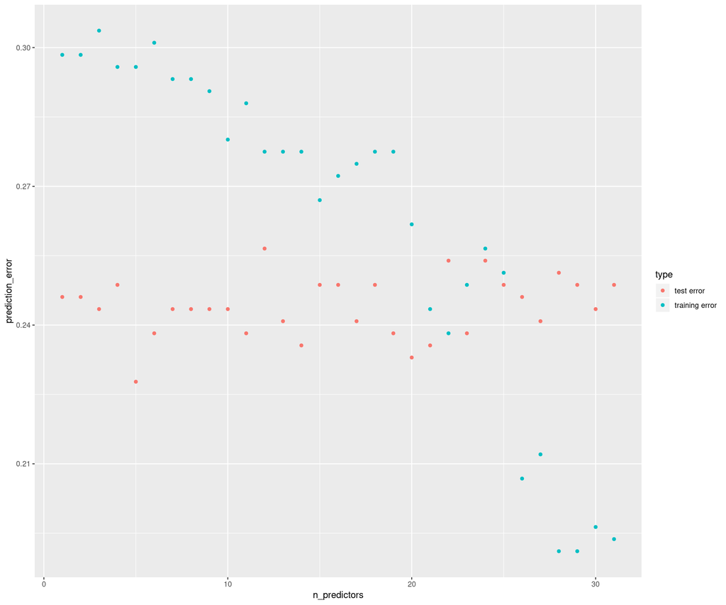

```r
predictors <- c('school', 'sex', 'age', 'address', 'famsize', 'Pstatus', 'Medu', 'Fedu', 'Mjob', 'Fjob', 'reason', 'nursery', 'internet', 'guardian', 'traveltime', 'studytime', 'failures', 'schoolsup', 'famsup', 'paid', 'activities', 'higher', 'romantic', 'famrel', 'freetime', 'goout', 'health', 'absences', 'G1', 'G2', 'G3')

# Fit several models and record the test and traingin errors
# 1) Use all of the predictors.
# 2) Drop one predictor and fit a new model.
# 3) Continue until only one predictor is left in the model.

test_error <- numeric(length(predictors))
training_error <- numeric(length(predictors))

for(i in length(predictors):1) {
  model_formula <- paste0("high_use ~ ", paste(predictors[1:i], collapse = " + "))
  glmfit <- glm(model_formula, data = alc, family = "binomial")
  cv <- cv.glm(data = alc, cost = loss_func, glmfit = m, K = 10)
  test_error[i] <- cv$delta[1]
  training_error[i] <- loss_func(alc$high_use, predict(glmfit,type="response"))
}

data_error <- rbind(data.frame(n_predictors=1:length(predictors),
                               prediction_error=test_error,
                               type = "test error"),
                    data.frame(n_predictors=1:length(predictors),
                               prediction_error=training_error,
                               type = "training error"))


g <- ggplot(data_error, aes(x = n_predictors, y = prediction_error, col=type))
g + geom_point()
```